# Probability Assignment

Brian D. Gerber

2022-09-01

### **Objective**: To familiarize yourself with probability functions.

### **Markdown**

Create a markdown file that shows and discusses 3 probability functions. An example is provided below as a guide. Which probability function to choose? If you are unfamiliar with any of these, please choose from here: Normal, Binomial, Poisson, Log-Normal, Beta. If you feel comfortable with these distributions then choose from a long list of options from [wikipedia](https://en.wikipedia.org/wiki/List_of_probability_distributions).

You should:

- Define the random variable $y$ that is $iid$ from your distribution
- Define the sample space and parameter space (for each)
- Include the equation of the probability function
- Define the expected value (mean) and variance of the distribution
- Visualize the pdf using 2 to 4 different sets of parameters
- Demonstrate using code how to calculate the probability of data over certain ranges (e.g. pnorm).
- Demonstrate how to find the values of data pertaining to a certain probability (e.g. qnorm).
- Plot a small and large sample from the distribution. Comment on whether the samples looks like the PDF.
- Provide an example of what type of data this probability function could be useful for

## Discrete Uniform

The discrete uniform distribution defines probabilities for a set of integer values ranging from a lower bound to an upper bound.

$$y \sim \text{Uniform}(a,b)$$

### **Support**

The support of the random variable $y$ is
$$y \in \{a, a+1,..., b-1, b\}$$

The support of the parameters $a$ and $b$ are all integers, where $b \geq a$, and $n = b-a+1$.

### **Probability Function**

$$f(y|a,b) = \frac{1}{n}$$

### **Mean/Variance**

$$E[y] = \frac{a+b}{2}\\
Var[Y] = \frac{n^2-1}{12}$$

### **Plotting**

Example 1

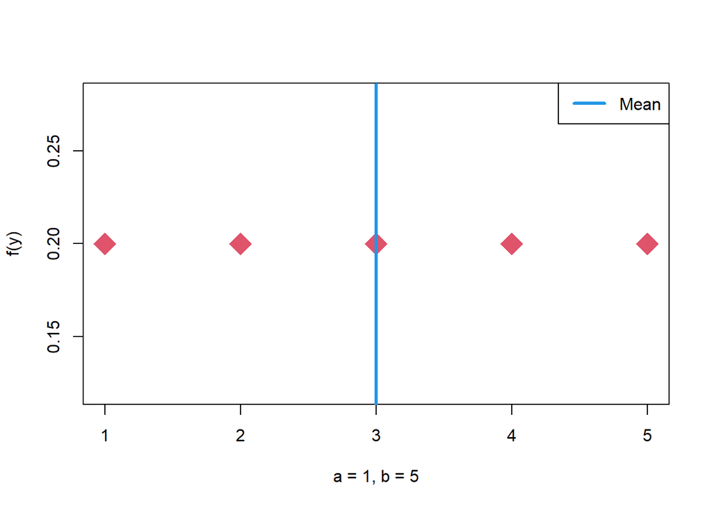

```r
#Parameters
  a=1; b=5
# Sample Space of RV
  x=seq(a,b,by=1)
  n=length(x)
#plotting probability mass
  plot(x,rep(1/n,length(x)),col=2,pch=18,cex=3,
     ylab="f(y)",xlab=c("a = 1, b = 5"))
     abline(v=(a+b)/2,lwd=3,col=4)
     legend("topright",lwd=3,col=4,legend=c("Mean"))
```

Example 2

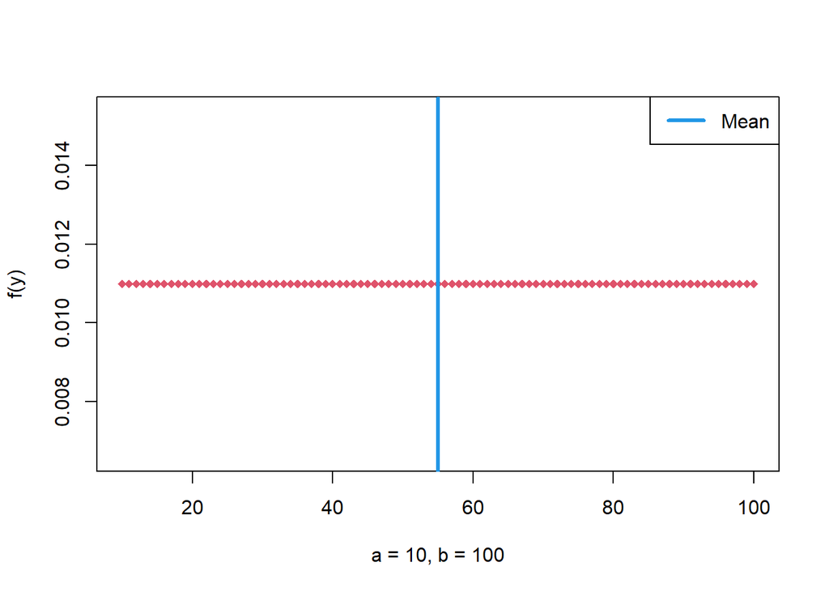

```r
#Parameters
  a=10; b=100
#Sample Space
  x=seq(a,b,by=1)
  n=length(x)
#plotting probability mass
  plot(x,rep(1/n,length(x)),col=2,pch=18,cex=1,
     ylab="f(y)",xlab=c("a = 10, b = 100"))
  abline(v=(a+b)/2,lwd=3,col=4)
  legend("topright",lwd=3,col=4,legend=c("Mean"))
```

### **Probability**

The probability of observing samples $\geq$ 60 when $a$ = 10 and $b$ =100 is,

```r
#Parameters
  a=10; b=100
#Sample space
  x=seq(a,b,by=1)
  n=length(x)
#Probability of any one value
  p=1/n
  p
```

```
## [1] 0.01098901
```

```r
#Add probabilities for all the integers >=60
  length(which(x>=60))*p
```

```
## [1] 0.4505495
```

### **Sampling**

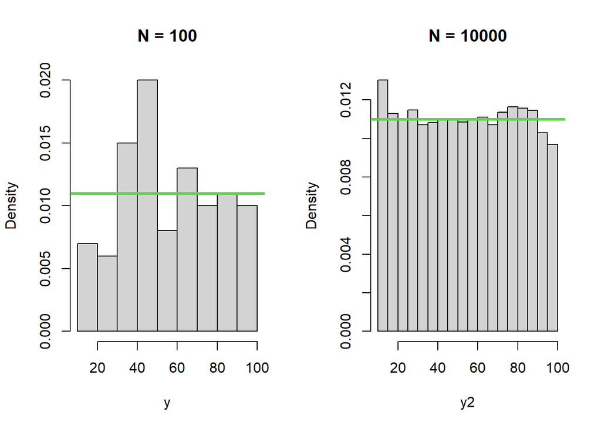

```r
#Parameters
  a=10; b=100

#Sample at different sample sizes
  sample.size=100
  sample.size2=10000

  y=round(runif(sample.size,a,b),digits=0)
  y2=round(runif(sample.size2,a,b),digits=0)

#plotting samples with True probability
  par(mfrow=c(1,2))

  hist(y,main="N = 100",freq = FALSE)
  abline(h=p,col=3,lwd=3)

  hist(y2,main="N = 10000",freq = FALSE)
  abline(h=p,col=3,lwd=3)
```

Even at a sample size of 10000, the probabilities are still a bit wonky from the truth, but close. Certainly a lot close to the sample size at 100.

### **Ecological Data**

The discrete uniform is not a very useful probability distribution for data. However, it is commonly used as a prior probability distribtion on parameters that can only be integers within a given range.